# Exploratory Data Analysis

### José Carlos Monescillo Calzado

#### **Objetivo**

El objetivo principal de esta práctica es emplear técnicas de **Análisis Exploratorio de Datos (EDA)** para comprender a fondo un conjunto de datos relacionado con solicitudes de préstamos. Este análisis busca **identificar patrones y relaciones** entre las variables que permitan predecir el comportamiento de los clientes respecto al cumplimiento o incumplimiento de sus pagos. En este sentido, se evaluarán tanto variables demográficas como características financieras de los solicitantes, para determinar su influencia en la capacidad de devolver un préstamo. Este objetivo incluye el análisis detallado de posibles correlaciones entre las variables, la imputación de valores nulos, la transformación de datos categóricos y numéricos, y el escalado de las características según sea necesario.

En última instancia, el propósito es responder a la pregunta clave de negocio planteada: **"¿Hay algún tipo de cliente más propenso a no devolver un préstamo?"**. Esto servirá como base para proponer estrategias que puedan mejorar la evaluación de riesgo y reducir las tasas de incumplimiento en futuras decisiones de crédito.

#### **Pasos**

1. **Exploración general** de los datos: se analizan la distribución de los datos y las relaciones entre las distintas variables en relación a la variable objetivo.
2. **Correlaciones**, **valores nulos** y **outliers**: se evaluan las correlaciones entre variables, se tratan los valores faltantes y los outliers. Se elaboran estrategias para su eliminación o tratamiento.
3. **Codificación y escalado**: se codifican las variables categóricas para poderlas emplearlas en el modelo. Se implementan las técnicas de OneHotEncoding y TargetEncoding en función de los valores únicos de cada variable.

#### **Caso de negocio**

El caso de negocio gira en torno a un banco que se especializa en ofrecer distintos tipos de préstamos a sus clientes. Actualmente, la institución enfrenta el desafío de **identificar a los solicitantes que representan un mayor riesgo de incumplimiento**. Para abordar este problema, se busca analizar el comportamiento histórico de los clientes que no han cumplido con sus pagos y establecer criterios claros para mitigar los riesgos en futuras operaciones de préstamo.

El análisis exploratorio se convierte, en este contexto, en una herramienta clave para segmentar a los clientes según sus características y establecer perfiles de riesgo más precisos. Al responder preguntas como qué tipo de clientes o condiciones financieras están más relacionadas con el incumplimiento, el banco puede mejorar sus procesos de evaluación crediticia.

# LIBRERIAS

```python
import pandas as pd
import numpy as np
import seaborn as sns
from matplotlib import pyplot as plt
import plotly.express as px



pd.set_option('display.max_columns', 500)
pd.set_option('display.max_rows', 5000)

seed=123
```

## Diccionario de datos

```python
ruta = '../data_practica_EDA/columns_description.xlsx'
dictionary = pd.read_excel(ruta, index_col=0)
dictionary
```

|  | Table | Row | Description | Special |
| --- | --- | --- | --- | --- |
| 1 | application_data | SK_ID_CURR | ID of loan in our sample | NaN |
| 2 | application_data | TARGET | Target variable (1 - client with payment diffi... | NaN |
| 5 | application_data | NAME_CONTRACT_TYPE | Identification if loan is cash or revolving | NaN |
| 6 | application_data | CODE_GENDER | Gender of the client | NaN |
| 7 | application_data | FLAG_OWN_CAR | Flag if the client owns a car | NaN |
| 8 | application_data | FLAG_OWN_REALTY | Flag if client owns a house or flat | NaN |
| 9 | application_data | CNT_CHILDREN | Number of children the client has | NaN |
| 10 | application_data | AMT_INCOME_TOTAL | Income of the client | NaN |
| 11 | application_data | AMT_CREDIT | Credit amount of the loan | NaN |
| 12 | application_data | AMT_ANNUITY | Loan annuity | NaN |
| 13 | application_data | AMT_GOODS_PRICE | For consumer loans it is the price of the good... | NaN |
| 14 | application_data | NAME_TYPE_SUITE | Who was accompanying client when he was applyi... | NaN |
| 15 | application_data | NAME_INCOME_TYPE | Clients income type (businessman, working, mat... | NaN |
| 16 | application_data | NAME_EDUCATION_TYPE | Level of highest education the client achieved | NaN |
| 17 | application_data | NAME_FAMILY_STATUS | Family status of the client | NaN |
| 18 | application_data | NAME_HOUSING_TYPE | What is the housing situation of the client (r... | NaN |
| 19 | application_data | REGION_POPULATION_RELATIVE | Normalized population of region where client l... | normalized |
| 20 | application_data | DAYS_BIRTH | Client's age in days at the time of application | time only relative to the application |
| 21 | application_data | DAYS_EMPLOYED | How many days before the application the perso... | time only relative to the application |
| 22 | application_data | DAYS_REGISTRATION | How many days before the application did clien... | time only relative to the application |
| 23 | application_data | DAYS_ID_PUBLISH | How many days before the application did clien... | time only relative to the application |
| 24 | application_data | OWN_CAR_AGE | Age of client's car | NaN |
| 25 | application_data | FLAG_MOBIL | Did client provide mobile phone (1=YES, 0=NO) | NaN |
| 26 | application_data | FLAG_EMP_PHONE | Did client provide work phone (1=YES, 0=NO) | NaN |
| 27 | application_data | FLAG_WORK_PHONE | Did client provide home phone (1=YES, 0=NO) | NaN |
| 28 | application_data | FLAG_CONT_MOBILE | Was mobile phone reachable (1=YES, 0=NO) | NaN |
| 29 | application_data | FLAG_PHONE | Did client provide home phone (1=YES, 0=NO) | NaN |
| 30 | application_data | FLAG_EMAIL | Did client provide email (1=YES, 0=NO) | NaN |
| 31 | application_data | OCCUPATION_TYPE | What kind of occupation does the client have | NaN |
| 32 | application_data | CNT_FAM_MEMBERS | How many family members does client have | NaN |

[output cut: 130 more lines]

# FUNCIONES

A partir del segundo notebook, todas las funciones que se emplearán estarán importadas desde el archivo "funciones_auxiliares".

```python
def dame_variables_categoricas(dataset=None, max_unicos=100):

    """ Se indica el valor de valores únicos máximo(max_unicos) como un parametro de manera que si lo escribimos a lo largo de la función
    más de una vez solo se tenga que cambiar en una línea.

    Inputs:
        -- dataset: pandas dataframe que contiene los datos
        -- max_unicos: máximo de unicos que se desean por columna(variable)
        """




    if dataset is None:
        print(u'\nFaltan argumentos por pasar a la función')
        return 1

    lista_variables_categoricas = []
    other = []

    for i in dataset.columns:
        unicos = int(len(np.unique(dataset[i].dropna(axis=0, how='all'))))
        if dataset[i].dtype in ['object', 'category'] or unicos < max_unicos: # A traves de la lista simplificamos el código.
                lista_variables_categoricas.append(i)
        else:
                other.append(i)

    return lista_variables_categoricas, other
```

```python
pd_loan = pd.read_csv('../data_practica_EDA/application_data.csv').set_index('SK_ID_CURR')
pd_loan
```

| SK_ID_CURR | TARGET | NAME_CONTRACT_TYPE | CODE_GENDER | FLAG_OWN_CAR | FLAG_OWN_REALTY | CNT_CHILDREN | AMT_INCOME_TOTAL | AMT_CREDIT | AMT_ANNUITY | AMT_GOODS_PRICE | NAME_TYPE_SUITE | NAME_INCOME_TYPE | NAME_EDUCATION_TYPE | NAME_FAMILY_STATUS | NAME_HOUSING_TYPE | REGION_POPULATION_RELATIVE | DAYS_BIRTH | DAYS_EMPLOYED | DAYS_REGISTRATION | DAYS_ID_PUBLISH | OWN_CAR_AGE | FLAG_MOBIL | FLAG_EMP_PHONE | FLAG_WORK_PHONE | FLAG_CONT_MOBILE | FLAG_PHONE | FLAG_EMAIL | OCCUPATION_TYPE | CNT_FAM_MEMBERS | … |
| --- | --- | --- | --- | --- | --- | --- | --- | --- | --- | --- | --- | --- | --- | --- | --- | --- | --- | --- | --- | --- | --- | --- | --- | --- | --- | --- | --- | --- | --- | --- |
| 100002 | 1 | Cash loans | M | N | Y | 0 | 202500.0 | 406597.5 | 24700.5 | 351000.0 | Unaccompanied | Working | Secondary / secondary special | Single / not married | House / apartment | 0.018801 | -9461 | -637 | -3648.0 | -2120 | NaN | 1 | 1 | 0 | 1 | 1 | 0 | Laborers | 1.0 | … |
| 100003 | 0 | Cash loans | F | N | N | 0 | 270000.0 | 1293502.5 | 35698.5 | 1129500.0 | Family | State servant | Higher education | Married | House / apartment | 0.003541 | -16765 | -1188 | -1186.0 | -291 | NaN | 1 | 1 | 0 | 1 | 1 | 0 | Core staff | 2.0 | … |
| 100004 | 0 | Revolving loans | M | Y | Y | 0 | 67500.0 | 135000.0 | 6750.0 | 135000.0 | Unaccompanied | Working | Secondary / secondary special | Single / not married | House / apartment | 0.010032 | -19046 | -225 | -4260.0 | -2531 | 26.0 | 1 | 1 | 1 | 1 | 1 | 0 | Laborers | 1.0 | … |
| 100006 | 0 | Cash loans | F | N | Y | 0 | 135000.0 | 312682.5 | 29686.5 | 297000.0 | Unaccompanied | Working | Secondary / secondary special | Civil marriage | House / apartment | 0.008019 | -19005 | -3039 | -9833.0 | -2437 | NaN | 1 | 1 | 0 | 1 | 0 | 0 | Laborers | 2.0 | … |
| 100007 | 0 | Cash loans | M | N | Y | 0 | 121500.0 | 513000.0 | 21865.5 | 513000.0 | Unaccompanied | Working | Secondary / secondary special | Single / not married | House / apartment | 0.028663 | -19932 | -3038 | -4311.0 | -3458 | NaN | 1 | 1 | 0 | 1 | 0 | 0 | Core staff | 1.0 | … |
| ... | ... | ... | ... | ... | ... | ... | ... | ... | ... | ... | ... | ... | ... | ... | ... | ... | ... | ... | ... | ... | ... | ... | ... | ... | ... | ... | ... | ... | ... | … |
| 456251 | 0 | Cash loans | M | N | N | 0 | 157500.0 | 254700.0 | 27558.0 | 225000.0 | Unaccompanied | Working | Secondary / secondary special | Separated | With parents | 0.032561 | -9327 | -236 | -8456.0 | -1982 | NaN | 1 | 1 | 0 | 1 | 0 | 0 | Sales staff | 1.0 | … |
| 456252 | 0 | Cash loans | F | N | Y | 0 | 72000.0 | 269550.0 | 12001.5 | 225000.0 | Unaccompanied | Pensioner | Secondary / secondary special | Widow | House / apartment | 0.025164 | -20775 | 365243 | -4388.0 | -4090 | NaN | 1 | 0 | 0 | 1 | 1 | 0 | NaN | 1.0 | … |
| 456253 | 0 | Cash loans | F | N | Y | 0 | 153000.0 | 677664.0 | 29979.0 | 585000.0 | Unaccompanied | Working | Higher education | Separated | House / apartment | 0.005002 | -14966 | -7921 | -6737.0 | -5150 | NaN | 1 | 1 | 0 | 1 | 0 | 1 | Managers | 1.0 | … |
| 456254 | 1 | Cash loans | F | N | Y | 0 | 171000.0 | 370107.0 | 20205.0 | 319500.0 | Unaccompanied | Commercial associate | Secondary / secondary special | Married | House / apartment | 0.005313 | -11961 | -4786 | -2562.0 | -931 | NaN | 1 | 1 | 0 | 1 | 0 | 0 | Laborers | 2.0 | … |
| 456255 | 0 | Cash loans | F | N | N | 0 | 157500.0 | 675000.0 | 49117.5 | 675000.0 | Unaccompanied | Commercial associate | Higher education | Married | House / apartment | 0.046220 | -16856 | -1262 | -5128.0 | -410 | NaN | 1 | 1 | 1 | 1 | 1 | 0 | Laborers | 2.0 | … |

307511 rows × 121 columns

Dimensión del dataset

```python
print(pd_loan.shape, pd_loan.drop_duplicates().shape)
```

```
(307511, 121) (307511, 121)
```

Tras la ejecución de este código en el que imprimimos la dimensión (columnas y filas) del dataset antes y después de la comprobación de duplicados, se observa que no se ha eliminado ningún registro, lo que indica que no hay duplicados. El dataframe está compuesto de **307.511 filas y 121 columnas**.

```python
pd_loan.dtypes.to_dict()
```

```
{'TARGET': dtype('int64'),
 'NAME_CONTRACT_TYPE': dtype('O'),
 'CODE_GENDER': dtype('O'),
 'FLAG_OWN_CAR': dtype('O'),
 'FLAG_OWN_REALTY': dtype('O'),
 'CNT_CHILDREN': dtype('int64'),
 'AMT_INCOME_TOTAL': dtype('float64'),
 'AMT_CREDIT': dtype('float64'),
 'AMT_ANNUITY': dtype('float64'),
 'AMT_GOODS_PRICE': dtype('float64'),
 'NAME_TYPE_SUITE': dtype('O'),
 'NAME_INCOME_TYPE': dtype('O'),
 'NAME_EDUCATION_TYPE': dtype('O'),
 'NAME_FAMILY_STATUS': dtype('O'),
 'NAME_HOUSING_TYPE': dtype('O'),
 'REGION_POPULATION_RELATIVE': dtype('float64'),
 'DAYS_BIRTH': dtype('int64'),
 'DAYS_EMPLOYED': dtype('int64'),
 'DAYS_REGISTRATION': dtype('float64'),
 'DAYS_ID_PUBLISH': dtype('int64'),
 'OWN_CAR_AGE': dtype('float64'),
 'FLAG_MOBIL': dtype('int64'),
 'FLAG_EMP_PHONE': dtype('int64'),
 'FLAG_WORK_PHONE': dtype('int64'),
 'FLAG_CONT_MOBILE': dtype('int64'),
 'FLAG_PHONE': dtype('int64'),
 'FLAG_EMAIL': dtype('int64'),
 'OCCUPATION_TYPE': dtype('O'),
 'CNT_FAM_MEMBERS': dtype('float64'),
 'REGION_RATING_CLIENT': dtype('int64'),
 'REGION_RATING_CLIENT_W_CITY': dtype('int64'),
 'WEEKDAY_APPR_PROCESS_START': dtype('O'),
 'HOUR_APPR_PROCESS_START': dtype('int64'),
 'REG_REGION_NOT_LIVE_REGION': dtype('int64'),
 'REG_REGION_NOT_WORK_REGION': dtype('int64'),
 'LIVE_REGION_NOT_WORK_REGION': dtype('int64'),
 'REG_CITY_NOT_LIVE_CITY': dtype('int64'),
 'REG_CITY_NOT_WORK_CITY': dtype('int64'),
 'LIVE_CITY_NOT_WORK_CITY': dtype('int64'),
 'ORGANIZATION_TYPE': dtype('O'),
```

[output cut: 66 more lines]

```
 'FLAG_DOCUMENT_13': dtype('int64'),
 'FLAG_DOCUMENT_14': dtype('int64'),
 'FLAG_DOCUMENT_15': dtype('int64'),
 'FLAG_DOCUMENT_16': dtype('int64'),
 'FLAG_DOCUMENT_17': dtype('int64'),
 'FLAG_DOCUMENT_18': dtype('int64'),
 'FLAG_DOCUMENT_19': dtype('int64'),
 'FLAG_DOCUMENT_20': dtype('int64'),
 'FLAG_DOCUMENT_21': dtype('int64'),
 'AMT_REQ_CREDIT_BUREAU_HOUR': dtype('float64'),
 'AMT_REQ_CREDIT_BUREAU_DAY': dtype('float64'),
 'AMT_REQ_CREDIT_BUREAU_WEEK': dtype('float64'),
 'AMT_REQ_CREDIT_BUREAU_MON': dtype('float64'),
 'AMT_REQ_CREDIT_BUREAU_QRT': dtype('float64'),
 'AMT_REQ_CREDIT_BUREAU_YEAR': dtype('float64')}
```

Se observa cada columna asociada a una variable y el tipo de variable que es, object o numéricas.

## Exploración de la variable objetivo

```python
pd_plot_target = pd_loan['TARGET']\
        .value_counts(normalize=True)\
        .mul(100).rename('percent').reset_index()

pd_plot_target_conteo = pd_loan['TARGET'].value_counts().reset_index()
pd_plot_target_pc = pd.merge(pd_plot_target, pd_plot_target_conteo, on=['TARGET'], how='inner')
pd_plot_target_pc
```

|  | TARGET | percent | count |
| --- | --- | --- | --- |
| 0 | 0 | 91.927118 | 282686 |
| 1 | 1 | 8.072882 | 24825 |

```python
fig = px.bar(pd_plot_target_pc, x="TARGET", y='percent', text='percent', labels={"TARGET": "Estado de Pago (TARGET)", "percent": "Porcentaje"})
fig.show()
```

[output not shown]

La variable 'TARGET' nos muestra si se ha producido retraso en el pago de las cuotas del préstamo. El 91.93% de los clientes han pagado las cuotas del prestamo sin retraso mientras que el 8.07% han tenido dificultades para pagar. En valores absolutos son 282686 quienes pagaron a tiempo frente a 24825 personas que se retrasaron en el pago. Se observa que la variable está desbalanceada.

## Selección de threshold (umbral) por filas y columnas para suprimir valores missing

```python
pd_series_null_columns = pd_loan.isnull().sum().sort_values(ascending=False)
pd_series_null_rows = pd_loan.isnull().sum(axis=1).sort_values(ascending=False)
print(pd_series_null_columns.shape, pd_series_null_rows.shape)

pd_null_columnas = pd.DataFrame(pd_series_null_columns, columns=['nulos_columnas'])
pd_null_filas = pd.DataFrame(pd_series_null_rows, columns=['nulos_filas'])
pd_null_filas['target'] = pd_loan['TARGET'].copy()
pd_null_columnas['porcentaje_columnas'] = pd_null_columnas['nulos_columnas']/pd_loan.shape[0]
pd_null_filas['porcentaje_filas']= pd_null_filas['nulos_filas']/pd_loan.shape[1]
```

```
(121,) (307511,)
```

```python
pd_loan.shape
```

```
(307511, 121)
```

```python
pd_null_columnas
```

|  | nulos_columnas | porcentaje_columnas |
| --- | --- | --- |
| COMMONAREA_AVG | 214865 | 0.698723 |
| COMMONAREA_MODE | 214865 | 0.698723 |
| COMMONAREA_MEDI | 214865 | 0.698723 |
| NONLIVINGAPARTMENTS_AVG | 213514 | 0.694330 |
| NONLIVINGAPARTMENTS_MODE | 213514 | 0.694330 |
| NONLIVINGAPARTMENTS_MEDI | 213514 | 0.694330 |
| FONDKAPREMONT_MODE | 210295 | 0.683862 |
| LIVINGAPARTMENTS_MEDI | 210199 | 0.683550 |
| LIVINGAPARTMENTS_AVG | 210199 | 0.683550 |
| LIVINGAPARTMENTS_MODE | 210199 | 0.683550 |
| FLOORSMIN_AVG | 208642 | 0.678486 |
| FLOORSMIN_MODE | 208642 | 0.678486 |
| FLOORSMIN_MEDI | 208642 | 0.678486 |
| YEARS_BUILD_AVG | 204488 | 0.664978 |
| YEARS_BUILD_MEDI | 204488 | 0.664978 |
| YEARS_BUILD_MODE | 204488 | 0.664978 |
| OWN_CAR_AGE | 202929 | 0.659908 |
| LANDAREA_MEDI | 182590 | 0.593767 |
| LANDAREA_AVG | 182590 | 0.593767 |
| LANDAREA_MODE | 182590 | 0.593767 |
| BASEMENTAREA_MEDI | 179943 | 0.585160 |
| BASEMENTAREA_AVG | 179943 | 0.585160 |
| BASEMENTAREA_MODE | 179943 | 0.585160 |
| EXT_SOURCE_1 | 173378 | 0.563811 |
| NONLIVINGAREA_AVG | 169682 | 0.551792 |
| NONLIVINGAREA_MODE | 169682 | 0.551792 |
| NONLIVINGAREA_MEDI | 169682 | 0.551792 |
| ELEVATORS_MODE | 163891 | 0.532960 |
| ELEVATORS_AVG | 163891 | 0.532960 |
| ELEVATORS_MEDI | 163891 | 0.532960 |

[output cut: 91 more lines]

```python
threshold=0.80
list_vars_not_null = list(pd_null_columnas[pd_null_columnas['porcentaje_columnas']<threshold].index)
pd_loan_filter_null = pd_loan.loc[:, list_vars_not_null]
pd_loan_filter_null.shape
```

```
(307511, 121)
```

Aunque un umbral menor (como 0.6) podría ser más estricto, se decidió conservar más columnas, ya que las proporciones de nulos no son consideradas excesivamente altas.

```python
pd_null_filas
```

| SK_ID_CURR | nulos_filas | target | porcentaje_filas |
| --- | --- | --- | --- |
| 315294 | 61 | 0 | 0.504132 |
| 255145 | 61 | 0 | 0.504132 |
| 329262 | 61 | 0 | 0.504132 |
| 235599 | 61 | 0 | 0.504132 |
| 412312 | 61 | 0 | 0.504132 |
| ... | ... | ... | ... |
| 250717 | 0 | 0 | 0.000000 |
| 250702 | 0 | 0 | 0.000000 |
| 250697 | 0 | 0 | 0.000000 |
| 250680 | 0 | 0 | 0.000000 |
| 278202 | 0 | 0 | 0.000000 |

307511 rows × 3 columns

La fila con mayor porcentaje de valores missing obtiene un 50% compartiendo valores con varias filas más.

```python
list_cat_vars, other = dame_variables_categoricas(dataset=pd_loan_filter_null)
pd_loan_filter_null[list_cat_vars] = pd_loan_filter_null[list_cat_vars].astype("category")
pd_loan_filter_null[list_cat_vars].head()
```

| SK_ID_CURR | FONDKAPREMONT_MODE | FLOORSMIN_MODE | FLOORSMIN_MEDI | OWN_CAR_AGE | ELEVATORS_MODE | ELEVATORS_MEDI | WALLSMATERIAL_MODE | ENTRANCES_MEDI | ENTRANCES_MODE | HOUSETYPE_MODE | FLOORSMAX_MEDI | FLOORSMAX_MODE | EMERGENCYSTATE_MODE | OCCUPATION_TYPE | AMT_REQ_CREDIT_BUREAU_WEEK | AMT_REQ_CREDIT_BUREAU_HOUR | AMT_REQ_CREDIT_BUREAU_MON | AMT_REQ_CREDIT_BUREAU_QRT | AMT_REQ_CREDIT_BUREAU_DAY | AMT_REQ_CREDIT_BUREAU_YEAR | NAME_TYPE_SUITE | DEF_30_CNT_SOCIAL_CIRCLE | OBS_60_CNT_SOCIAL_CIRCLE | OBS_30_CNT_SOCIAL_CIRCLE | DEF_60_CNT_SOCIAL_CIRCLE | CNT_FAM_MEMBERS | FLAG_DOCUMENT_8 | CODE_GENDER | FLAG_OWN_CAR | … |
| --- | --- | --- | --- | --- | --- | --- | --- | --- | --- | --- | --- | --- | --- | --- | --- | --- | --- | --- | --- | --- | --- | --- | --- | --- | --- | --- | --- | --- | --- | --- |
| 100002 | reg oper account | 0.1250 | 0.1250 | NaN | 0.0000 | 0.00 | Stone, brick | 0.0690 | 0.0690 | block of flats | 0.0833 | 0.0833 | No | Laborers | 0.0 | 0.0 | 0.0 | 0.0 | 0.0 | 1.0 | Unaccompanied | 2.0 | 2.0 | 2.0 | 2.0 | 1.0 | 0 | M | N | … |
| 100003 | reg oper account | 0.3333 | 0.3333 | NaN | 0.0806 | 0.08 | Block | 0.0345 | 0.0345 | block of flats | 0.2917 | 0.2917 | No | Core staff | 0.0 | 0.0 | 0.0 | 0.0 | 0.0 | 0.0 | Family | 0.0 | 1.0 | 1.0 | 0.0 | 2.0 | 0 | F | N | … |
| 100004 | NaN | NaN | NaN | 26.0 | NaN | NaN | NaN | NaN | NaN | NaN | NaN | NaN | NaN | Laborers | 0.0 | 0.0 | 0.0 | 0.0 | 0.0 | 0.0 | Unaccompanied | 0.0 | 0.0 | 0.0 | 0.0 | 1.0 | 0 | M | Y | … |
| 100006 | NaN | NaN | NaN | NaN | NaN | NaN | NaN | NaN | NaN | NaN | NaN | NaN | NaN | Laborers | NaN | NaN | NaN | NaN | NaN | NaN | Unaccompanied | 0.0 | 2.0 | 2.0 | 0.0 | 2.0 | 0 | F | N | … |
| 100007 | NaN | NaN | NaN | NaN | NaN | NaN | NaN | NaN | NaN | NaN | NaN | NaN | NaN | Core staff | 0.0 | 0.0 | 0.0 | 0.0 | 0.0 | 0.0 | Unaccompanied | 0.0 | 0.0 | 0.0 | 0.0 | 1.0 | 1 | M | N | … |

```python
list_cat_vars
```

```
['FONDKAPREMONT_MODE',
 'FLOORSMIN_MODE',
 'FLOORSMIN_MEDI',
 'OWN_CAR_AGE',
 'ELEVATORS_MODE',
 'ELEVATORS_MEDI',
 'WALLSMATERIAL_MODE',
 'ENTRANCES_MEDI',
 'ENTRANCES_MODE',
 'HOUSETYPE_MODE',
 'FLOORSMAX_MEDI',
 'FLOORSMAX_MODE',
 'EMERGENCYSTATE_MODE',
 'OCCUPATION_TYPE',
 'AMT_REQ_CREDIT_BUREAU_WEEK',
 'AMT_REQ_CREDIT_BUREAU_HOUR',
 'AMT_REQ_CREDIT_BUREAU_MON',
 'AMT_REQ_CREDIT_BUREAU_QRT',
 'AMT_REQ_CREDIT_BUREAU_DAY',
 'AMT_REQ_CREDIT_BUREAU_YEAR',
 'NAME_TYPE_SUITE',
 'DEF_30_CNT_SOCIAL_CIRCLE',
 'OBS_60_CNT_SOCIAL_CIRCLE',
 'OBS_30_CNT_SOCIAL_CIRCLE',
 'DEF_60_CNT_SOCIAL_CIRCLE',
 'CNT_FAM_MEMBERS',
 'FLAG_DOCUMENT_8',
 'CODE_GENDER',
 'FLAG_OWN_CAR',
 'FLAG_OWN_REALTY',
 'FLAG_DOCUMENT_2',
 'FLAG_DOCUMENT_3',
 'FLAG_DOCUMENT_4',
 'FLAG_DOCUMENT_5',
 'FLAG_DOCUMENT_6',
 'FLAG_DOCUMENT_7',
 'FLAG_DOCUMENT_9',
 'FLAG_DOCUMENT_21',
 'FLAG_DOCUMENT_10',
 'FLAG_DOCUMENT_11',
```

[output cut: 19 more lines]

```
 'HOUR_APPR_PROCESS_START',
 'WEEKDAY_APPR_PROCESS_START',
 'REGION_RATING_CLIENT_W_CITY',
 'REGION_RATING_CLIENT',
 'FLAG_EMAIL',
 'FLAG_PHONE',
 'FLAG_CONT_MOBILE',
 'FLAG_WORK_PHONE',
 'FLAG_EMP_PHONE',
 'FLAG_MOBIL',
 'REGION_POPULATION_RELATIVE',
 'NAME_HOUSING_TYPE',
 'NAME_FAMILY_STATUS',
 'NAME_EDUCATION_TYPE',
 'TARGET']
```

```python
other
```

```
['COMMONAREA_AVG',
 'COMMONAREA_MODE',
 'COMMONAREA_MEDI',
 'NONLIVINGAPARTMENTS_AVG',
 'NONLIVINGAPARTMENTS_MODE',
 'NONLIVINGAPARTMENTS_MEDI',
 'LIVINGAPARTMENTS_MEDI',
 'LIVINGAPARTMENTS_AVG',
 'LIVINGAPARTMENTS_MODE',
 'FLOORSMIN_AVG',
 'YEARS_BUILD_AVG',
 'YEARS_BUILD_MEDI',
 'YEARS_BUILD_MODE',
 'LANDAREA_MEDI',
 'LANDAREA_AVG',
 'LANDAREA_MODE',
 'BASEMENTAREA_MEDI',
 'BASEMENTAREA_AVG',
 'BASEMENTAREA_MODE',
 'EXT_SOURCE_1',
 'NONLIVINGAREA_AVG',
 'NONLIVINGAREA_MODE',
 'NONLIVINGAREA_MEDI',
 'ELEVATORS_AVG',
 'APARTMENTS_AVG',
 'APARTMENTS_MEDI',
 'APARTMENTS_MODE',
 'ENTRANCES_AVG',
 'LIVINGAREA_MEDI',
 'LIVINGAREA_MODE',
 'LIVINGAREA_AVG',
 'FLOORSMAX_AVG',
 'YEARS_BEGINEXPLUATATION_MEDI',
 'YEARS_BEGINEXPLUATATION_MODE',
 'YEARS_BEGINEXPLUATATION_AVG',
 'TOTALAREA_MODE',
 'EXT_SOURCE_3',
 'EXT_SOURCE_2',
 'AMT_GOODS_PRICE',
 'AMT_ANNUITY',
 'DAYS_LAST_PHONE_CHANGE',
 'AMT_INCOME_TOTAL',
 'AMT_CREDIT',
 'DAYS_ID_PUBLISH',
 'DAYS_REGISTRATION',
 'DAYS_EMPLOYED',
 'DAYS_BIRTH']
```

Echamos un vistazo a las listas de variables categóricas y otras.

```python
len(list_cat_vars)
```

```
74
```

```python
len(other)
```

```
47
```

Se observa que hemos obtenido 74 variables categóricas y 47 no categóricas.

```python
pd_loan_filter_null[list_cat_vars].dtypes
```

```
FONDKAPREMONT_MODE             category
FLOORSMIN_MODE                 category
FLOORSMIN_MEDI                 category
OWN_CAR_AGE                    category
ELEVATORS_MODE                 category
ELEVATORS_MEDI                 category
WALLSMATERIAL_MODE             category
ENTRANCES_MEDI                 category
ENTRANCES_MODE                 category
HOUSETYPE_MODE                 category
FLOORSMAX_MEDI                 category
FLOORSMAX_MODE                 category
EMERGENCYSTATE_MODE            category
OCCUPATION_TYPE                category
AMT_REQ_CREDIT_BUREAU_WEEK     category
AMT_REQ_CREDIT_BUREAU_HOUR     category
AMT_REQ_CREDIT_BUREAU_MON      category
AMT_REQ_CREDIT_BUREAU_QRT      category
AMT_REQ_CREDIT_BUREAU_DAY      category
AMT_REQ_CREDIT_BUREAU_YEAR     category
NAME_TYPE_SUITE                category
DEF_30_CNT_SOCIAL_CIRCLE       category
OBS_60_CNT_SOCIAL_CIRCLE       category
OBS_30_CNT_SOCIAL_CIRCLE       category
DEF_60_CNT_SOCIAL_CIRCLE       category
CNT_FAM_MEMBERS                category
FLAG_DOCUMENT_8                category
CODE_GENDER                    category
FLAG_OWN_CAR                   category
FLAG_OWN_REALTY                category
FLAG_DOCUMENT_2                category
FLAG_DOCUMENT_3                category
FLAG_DOCUMENT_4                category
FLAG_DOCUMENT_5                category
FLAG_DOCUMENT_6                category
FLAG_DOCUMENT_7                category
FLAG_DOCUMENT_9                category
FLAG_DOCUMENT_21               category
FLAG_DOCUMENT_10               category
FLAG_DOCUMENT_11               category
```

[output cut: 20 more lines]

```
WEEKDAY_APPR_PROCESS_START     category
REGION_RATING_CLIENT_W_CITY    category
REGION_RATING_CLIENT           category
FLAG_EMAIL                     category
FLAG_PHONE                     category
FLAG_CONT_MOBILE               category
FLAG_WORK_PHONE                category
FLAG_EMP_PHONE                 category
FLAG_MOBIL                     category
REGION_POPULATION_RELATIVE     category
NAME_HOUSING_TYPE              category
NAME_FAMILY_STATUS             category
NAME_EDUCATION_TYPE            category
TARGET                         category
dtype: object
```

```python
income_counts = pd_loan_filter_null['NAME_INCOME_TYPE'].value_counts()
income_percentages = pd_loan_filter_null['NAME_INCOME_TYPE'].value_counts(normalize=True) # Expreso los porcentajes de manera que podamos apreciar mejor los datos ya que en valor absoluto no somos conscientes del valor que pueden tener.

income_summary = pd.DataFrame({
    'Count': income_counts,
    'Percentage': income_percentages.round(2)
})
income_summary
```

| NAME_INCOME_TYPE | Count | Percentage |
| --- | --- | --- |
| Working | 158774 | 0.52 |
| Commercial associate | 71617 | 0.23 |
| Pensioner | 55362 | 0.18 |
| State servant | 21703 | 0.07 |
| Unemployed | 22 | 0.00 |
| Student | 18 | 0.00 |
| Businessman | 10 | 0.00 |
| Maternity leave | 5 | 0.00 |

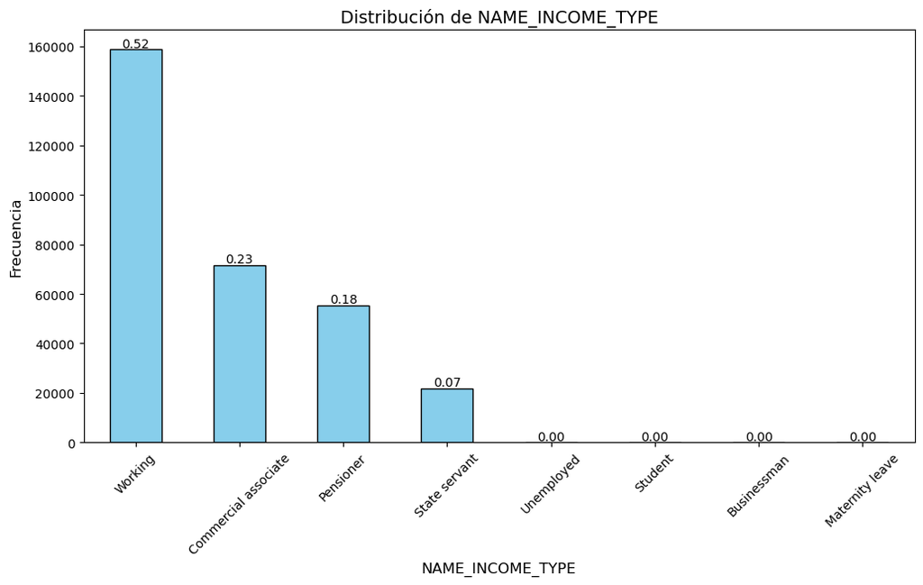

```python
plt.figure(figsize=(12, 6))
income_counts.plot(kind='bar', color='skyblue', edgecolor='black')
for i, (count, percentage) in enumerate(zip(income_counts, income_percentages)):
    plt.text(i, count + 1000, f'{percentage:.2f}', ha='center', fontsize=10)
plt.title('Distribución de NAME_INCOME_TYPE', fontsize=14)
plt.ylabel('Frecuencia', fontsize=12)
plt.xlabel('NAME_INCOME_TYPE', fontsize=12)
plt.xticks(rotation=45)
plt.show()
```

```python
contract_type_counts = pd_loan_filter_null['NAME_CONTRACT_TYPE'].value_counts()
contract_type_percentage = pd_loan_filter_null['NAME_CONTRACT_TYPE'].value_counts(normalize=True)
contract_type_summary = pd.DataFrame({
    'Count': contract_type_counts,
    'Percentage': contract_type_percentage
})
contract_type_summary
```

| NAME_CONTRACT_TYPE | Count | Percentage |
| --- | --- | --- |
| Cash loans | 278232 | 0.904787 |
| Revolving loans | 29279 | 0.095213 |

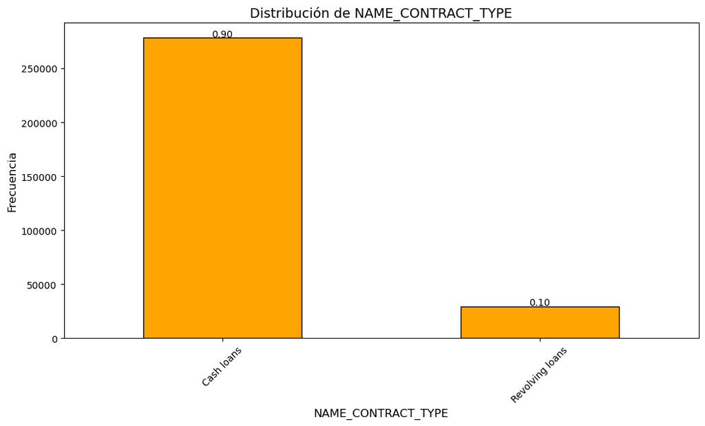

```python
plt.figure(figsize=(12, 6))
contract_type_counts.plot(kind='bar', color='orange', edgecolor='black')
for i, (count, percentage) in enumerate(zip(contract_type_counts, contract_type_percentage)):
    plt.text(i, count + 1000, f'{percentage:.2f}', ha='center', fontsize=10)
plt.title('Distribución de NAME_CONTRACT_TYPE', fontsize=14)
plt.ylabel('Frecuencia', fontsize=12)
plt.xlabel('NAME_CONTRACT_TYPE', fontsize=12)
plt.xticks(rotation=45)
plt.show()
```

Se observa que la mayoría de los préstamos son otorgados a trabajadores (más del 50%), seguido de comerciales asociados (23%) mientras que grupos como estudiantes, desempleados o empresarios son mucho menos frecuentes.

Por otro lado, los resultados de la celda 27 muestran que la mayoría de los préstamos en el dataset son "Cash loans" (préstamos en efectivo), con 278.232 registros (90%), mientras que los "Revolving loans" (préstamos rotativos) son mucho menos comunes, con 29.279 registros (10%). Esto sugiere que los clientes del dataset suelen preferir préstamos tradicionales con cantidades fijas y plazos definidos, mientras que el uso de créditos flexibles es significativamente menor.

```python
pd_loan_filter_null[other].head(10)
```

| SK_ID_CURR | COMMONAREA_AVG | COMMONAREA_MODE | COMMONAREA_MEDI | NONLIVINGAPARTMENTS_AVG | NONLIVINGAPARTMENTS_MODE | NONLIVINGAPARTMENTS_MEDI | LIVINGAPARTMENTS_MEDI | LIVINGAPARTMENTS_AVG | LIVINGAPARTMENTS_MODE | FLOORSMIN_AVG | YEARS_BUILD_AVG | YEARS_BUILD_MEDI | YEARS_BUILD_MODE | LANDAREA_MEDI | LANDAREA_AVG | LANDAREA_MODE | BASEMENTAREA_MEDI | BASEMENTAREA_AVG | BASEMENTAREA_MODE | EXT_SOURCE_1 | NONLIVINGAREA_AVG | NONLIVINGAREA_MODE | NONLIVINGAREA_MEDI | ELEVATORS_AVG | APARTMENTS_AVG | APARTMENTS_MEDI | APARTMENTS_MODE | ENTRANCES_AVG | LIVINGAREA_MEDI | … |
| --- | --- | --- | --- | --- | --- | --- | --- | --- | --- | --- | --- | --- | --- | --- | --- | --- | --- | --- | --- | --- | --- | --- | --- | --- | --- | --- | --- | --- | --- | --- |
| 100002 | 0.0143 | 0.0144 | 0.0144 | 0.0000 | 0.0 | 0.0000 | 0.0205 | 0.0202 | 0.022 | 0.1250 | 0.6192 | 0.6243 | 0.6341 | 0.0375 | 0.0369 | 0.0377 | 0.0369 | 0.0369 | 0.0383 | 0.083037 | 0.0000 | 0.0 | 0.00 | 0.00 | 0.0247 | 0.0250 | 0.0252 | 0.0690 | 0.0193 | … |
| 100003 | 0.0605 | 0.0497 | 0.0608 | 0.0039 | 0.0 | 0.0039 | 0.0787 | 0.0773 | 0.079 | 0.3333 | 0.7960 | 0.7987 | 0.8040 | 0.0132 | 0.0130 | 0.0128 | 0.0529 | 0.0529 | 0.0538 | 0.311267 | 0.0098 | 0.0 | 0.01 | 0.08 | 0.0959 | 0.0968 | 0.0924 | 0.0345 | 0.0558 | … |
| 100004 | NaN | NaN | NaN | NaN | NaN | NaN | NaN | NaN | NaN | NaN | NaN | NaN | NaN | NaN | NaN | NaN | NaN | NaN | NaN | NaN | NaN | NaN | NaN | NaN | NaN | NaN | NaN | NaN | NaN | … |
| 100006 | NaN | NaN | NaN | NaN | NaN | NaN | NaN | NaN | NaN | NaN | NaN | NaN | NaN | NaN | NaN | NaN | NaN | NaN | NaN | NaN | NaN | NaN | NaN | NaN | NaN | NaN | NaN | NaN | NaN | … |
| 100007 | NaN | NaN | NaN | NaN | NaN | NaN | NaN | NaN | NaN | NaN | NaN | NaN | NaN | NaN | NaN | NaN | NaN | NaN | NaN | NaN | NaN | NaN | NaN | NaN | NaN | NaN | NaN | NaN | NaN | … |
| 100008 | NaN | NaN | NaN | NaN | NaN | NaN | NaN | NaN | NaN | NaN | NaN | NaN | NaN | NaN | NaN | NaN | NaN | NaN | NaN | NaN | NaN | NaN | NaN | NaN | NaN | NaN | NaN | NaN | NaN | … |
| 100009 | NaN | NaN | NaN | NaN | NaN | NaN | NaN | NaN | NaN | NaN | NaN | NaN | NaN | NaN | NaN | NaN | NaN | NaN | NaN | 0.774761 | NaN | NaN | NaN | NaN | NaN | NaN | NaN | NaN | NaN | … |
| 100010 | NaN | NaN | NaN | NaN | NaN | NaN | NaN | NaN | NaN | NaN | NaN | NaN | NaN | NaN | NaN | NaN | NaN | NaN | NaN | NaN | NaN | NaN | NaN | NaN | NaN | NaN | NaN | NaN | NaN | … |
| 100011 | NaN | NaN | NaN | NaN | NaN | NaN | NaN | NaN | NaN | NaN | NaN | NaN | NaN | NaN | NaN | NaN | NaN | NaN | NaN | 0.587334 | NaN | NaN | NaN | NaN | NaN | NaN | NaN | NaN | NaN | … |
| 100012 | NaN | NaN | NaN | NaN | NaN | NaN | NaN | NaN | NaN | NaN | NaN | NaN | NaN | NaN | NaN | NaN | NaN | NaN | NaN | NaN | NaN | NaN | NaN | NaN | NaN | NaN | NaN | NaN | NaN | … |

```python
print(pd_loan_filter_null["OCCUPATION_TYPE"].value_counts().count())
pd_loan_filter_null["OCCUPATION_TYPE"]\
    .apply(lambda x: str(x).lower().strip()).value_counts(normalize=True)
```

```
18
```

```
OCCUPATION_TYPE
laborers                 0.261396
sales staff              0.152056
core staff               0.130589
managers                 0.101227
drivers                  0.088116
high skill tech staff    0.053903
accountants              0.046481
medicine staff           0.040437
security staff           0.031835
cooking staff            0.028164
cleaning staff           0.022040
private service staff    0.012562
low-skill laborers       0.009914
waiters/barmen staff     0.006385
secretaries              0.006181
realty agents            0.003557
hr staff                 0.002667
it staff                 0.002491
Name: proportion, dtype: float64
```

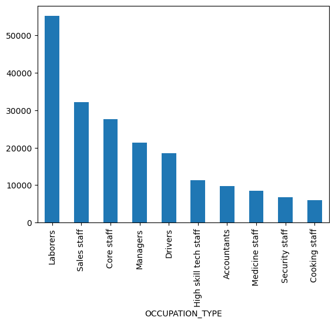

```python
top_occupation = pd_loan_filter_null['OCCUPATION_TYPE'].value_counts().head(10)
top_occupation.plot(kind='bar')
```

## Preprocesamiento inicial de algunas variables

```python
pd_loan_filter_null.to_csv('./pd_data_initial_preprocessing.csv')
```